# ENMeval

Rob Harbert and Peter Galante

5/15/2018

# ENMeval

Load libraries

```r
require(dismo)
require(ENMeval)
require(phyloclim)
require(sp)
require(rgdal)
require(rgeos)
require(ENMTools)
require(spocc)
```

Get data from GBIF

```r
#occ = occ('Ambystoma opacum', from = 'gbif', limit=10000)
occ = occ('Quercus virginiana', from = 'gbif')
occdf = occ2df(occ)
summary(occ)
```

[output not shown]

```r
loc = cbind(occdf$longitude, occdf$latitude)
loc = loc[loc[,1]<= -60,]
loc = na.omit(loc)
```

Load WorldClim

```r
# Env = stack("/data/spbio/climgrids/bio.gri")
Env = stack("~/bio.gri")
ext = extent(c(-100, - 60, 25, 55))
Env = crop(Env, ext)
```

Maxent

```r
max = maxent(Env, loc)
pred = predict(Env, max)
```

ENMeval

```r
require(ENMeval)
extr = extract(Env, loc)
loc = loc[!is.na(extr[,1]),]

res = ENMevaluate(occ=loc, env = Env, method='block', parallel=T, numCores=4, fc=c("L", "LQ", "H"), RMvalues=seq(0.5,4,0.5), rasterPreds=F)
```

```
## Doing evaluations using spatial blocks...
```

```
## Of 4 total cores using 4
```

```
## Running in parallel...
```

```
## ENMeval completed in 3 minutes 36.8 seconds.
```

```r
print(res@results)
```

```
##    settings features  rm full.AUC  Mean.AUC     Var.AUC Mean.AUC.DIFF
## 1     L_0.5        L 0.5   0.9697 0.9569684 0.003429567    0.02230974
## 2    LQ_0.5       LQ 0.5   0.9738 0.9574020 0.002265401    0.02123469
## 3     H_0.5        H 0.5   0.5266 0.8696230 0.003337644    0.05431994
## 4       L_1        L 1.0   0.9696 0.9544510 0.003443974    0.02226292
## 5      LQ_1       LQ 1.0   0.9726 0.9570222 0.002139333    0.02159246
## 6       H_1        H 1.0   0.9801 0.9160309 0.017145005    0.04864855
## 7     L_1.5        L 1.5   0.9694 0.9559225 0.003515027    0.02161554
## 8    LQ_1.5       LQ 1.5   0.9721 0.9538468 0.001923180    0.02499574
## 9     H_1.5        H 1.5   0.9800 0.9219303 0.012742220    0.04610627
## 10      L_2        L 2.0   0.9686 0.9570515 0.003648001    0.02137069
## 11     LQ_2       LQ 2.0   0.9718 0.9560926 0.001845243    0.02267767
## 12      H_2        H 2.0   0.9786 0.9517008 0.006418386    0.03275595
## 13    L_2.5        L 2.5   0.9684 0.9572677 0.003656116    0.02095777
## 14   LQ_2.5       LQ 2.5   0.9715 0.9541847 0.001920868    0.02468450
```

[output cut: 60 more lines]

```r
require(spThin)
df = data.frame(occdf)
extr = extract(Env, cbind(df$longitude, df$latitude))
df = df[!is.na(extr[,1]),]

thin<-thin(loc.data = df,
               lat.col = "latitude",
               long.col = "longitude",
               spec.col = "name",
               thin.par = 10,
               reps = 10,
               locs.thinned.list.return = T,
               write.files = T,
               max.files = 2,
               out.dir = "Thinlocs/",
               write.log.file = T)
```

```
##  Beginning Spatial Thinning.
##  Script Started at: Wed May 16 16:00:30 2018
## lat.long.thin.count
## 203
##  10
## [1] "Maximum number of records after thinning: 203"
## [1] "Number of data.frames with max records: 10"
## [1] "Writing new *.csv files"
```

```
## [1] "Writing file: Thinlocs/thinned_data_thin1_new_new.csv"
```

```
## [1] "Writing file: Thinlocs/thinned_data_thin2_new_new.csv"
```

```r
newthin = read.csv('Thinlocs/thinned_data_thin1.csv')
```

Re-run ENMeval

```r
thinres = ENMevaluate(occ=newthin[,2:3], env = Env, method='block', parallel=T, numCores=4, fc=c("L", "LQ", "H"), RMvalues=seq(1,4,1), rasterPreds=F)
```

```
## Doing evaluations using spatial blocks...
```

```
## Of 4 total cores using 4
```

```
## Running in parallel...
```

```
## ENMeval completed in 2 minutes 8.7 seconds.
```

```r
print(thinres@results)
```

```
##    settings features rm full.AUC  Mean.AUC     Var.AUC Mean.AUC.DIFF
## 1       L_1        L  1   0.9669 0.9561117 0.002658811    0.02010466
## 2      LQ_1       LQ  1   0.9705 0.9613613 0.001222391    0.01485223
## 3       H_1        H  1   0.9748 0.7980157 0.300175882    0.12336765
## 4       L_2        L  2   0.9659 0.9564613 0.003093781    0.02004019
## 5      LQ_2       LQ  2   0.9699 0.9619874 0.001190614    0.01407087
## 6       H_2        H  2   0.9722 0.9633446 0.001978232    0.01761102
## 7       L_3        L  3   0.9651 0.9568635 0.003175750    0.01946517
## 8      LQ_3       LQ  3   0.9695 0.9617705 0.001184982    0.01378699
## 9       H_3        H  3   0.9710 0.9623671 0.002170074    0.01777951
## 10      L_4        L  4   0.9642 0.9583281 0.002747695    0.01756281
## 11     LQ_4       LQ  4   0.9688 0.9618434 0.001262957    0.01360482
## 12      H_4        H  4   0.9693 0.9610099 0.001978685    0.01762392
##    Var.AUC.DIFF Mean.OR10   Var.OR10  Mean.ORmin    Var.ORmin AICc
## 1   0.001905733 0.2270588 0.08073264 0.005000000 0.0001000000   NA
```

[output cut: 24 more lines]

Check out the pattern of model fitting:

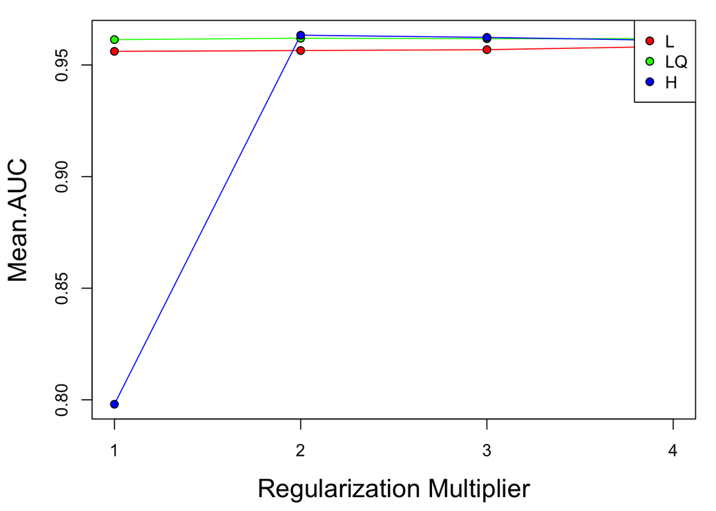

```r
eval.plot(thinres@results, "Mean.AUC", )
```

### “Best” models

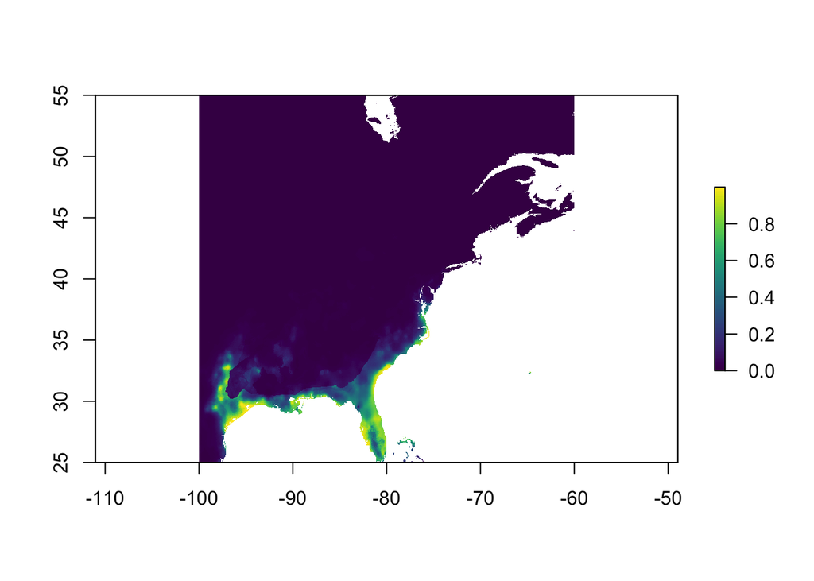

```r
#minimize ommission rate AND optimize AUC


setsort = res@results[order(res@results[,'Mean.ORmin']),]
setsort2 = setsort[order(setsort[,'Mean.AUC'], decreasing=TRUE),]
top = setsort2[1,]
best = which(as.character(res@results[,1]) == as.character(setsort2[1,1]))
pred.raw = predict(Env, res@models[[best]])
plot(pred.raw, col=viridis::viridis(99))

#and for the thinned model...
setsort = thinres@results[order(thinres@results[,'Mean.ORmin']),]
setsort2 = setsort[order(setsort[,'Mean.AUC'], decreasing=TRUE),]
top = setsort2[1,]
best.thin = which(as.character(thinres@results[,1]) == as.character(setsort2[1,1]))
pred.thin = predict(Env, thinres@models[[best.thin]])
plot(pred.raw, col=viridis::viridis(99))
```

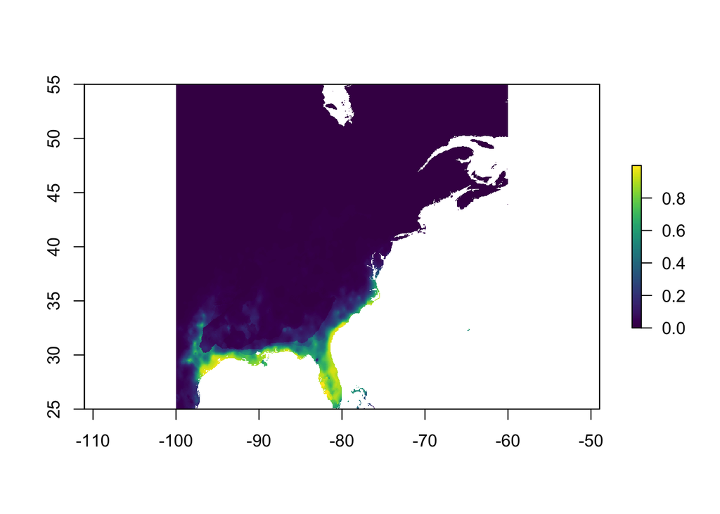

```r
plot(pred.thin, col=viridis::viridis(99))
```

Did you get different models parameters? Output? Which was more complex? Which performed better?

```r
print(res@results[best,])
```

```
##    settings features  rm full.AUC  Mean.AUC     Var.AUC Mean.AUC.DIFF
## 15    H_2.5        H 2.5   0.9776 0.9588992 0.003928384    0.02599059
##    Var.AUC.DIFF Mean.OR10  Var.OR10 Mean.ORmin    Var.ORmin AICc
## 15  0.003567986 0.3005618 0.1315806 0.01123596 0.0005049867   NA
##    delta.AICc w.AIC nparam
## 15         NA    NA     47
```

```r
print(thinres@results[best.thin,])
```

```
##   settings features rm full.AUC  Mean.AUC     Var.AUC Mean.AUC.DIFF
## 6      H_2        H  2   0.9722 0.9633446 0.001978232    0.01761102
##   Var.AUC.DIFF Mean.OR10   Var.OR10  Mean.ORmin    Var.ORmin AICc
## 6  0.001594909  0.202451 0.06198481 0.009901961 0.0001307574   NA
##   delta.AICc w.AIC nparam
## 6         NA    NA     45
```

### Binary Range – Thresholding

```r
#via dismo
#Get straight from ENMeval output:
ev.set <- evaluate(newthin[,2:3], thinres@bg.pts, thinres@models[[best.thin]], Env)
th1 = threshold(ev.set)
p1.nomit = pred.thin >= th1$no_omission
p1.equal = pred.thin >= th1$equal_sens_spec


#OR: calculate evaluation from predicted model output:
occ <- na.omit(extract(pred.thin, newthin[,2:3]));
bg = randomPoints(Env[[1]], n=20000)
bg <- na.omit(extract(pred.thin, bg));
ev2 <- evaluate(occ, bg)
th2 = threshold(ev2)
p2.nomit = pred.thin >= th2$no_omission
p2.equal = pred.thin >= th2$equal_sens_spec

#p1 and p2 should be virtually identical
```

Look at object ‘th’ for other threshold options.

### Niche overlap –

Warren, D.L., R.E. Glor, M. Turelli, and D. Funk. 2009. Environmental niche equivalency versus conservatism: quantitative approaches to niche evolution. Evolution 62:2868-2883; Erratum: Evolution 65: 1215

```r
#Values closer to 1 indicate stronger niche overlap
nicheOverlap(pred.raw, pred.thin, "D", mask=T)
```

```
## [1] 0.8786465
```

### Get background data from minimum convex polygon of occurrence data.

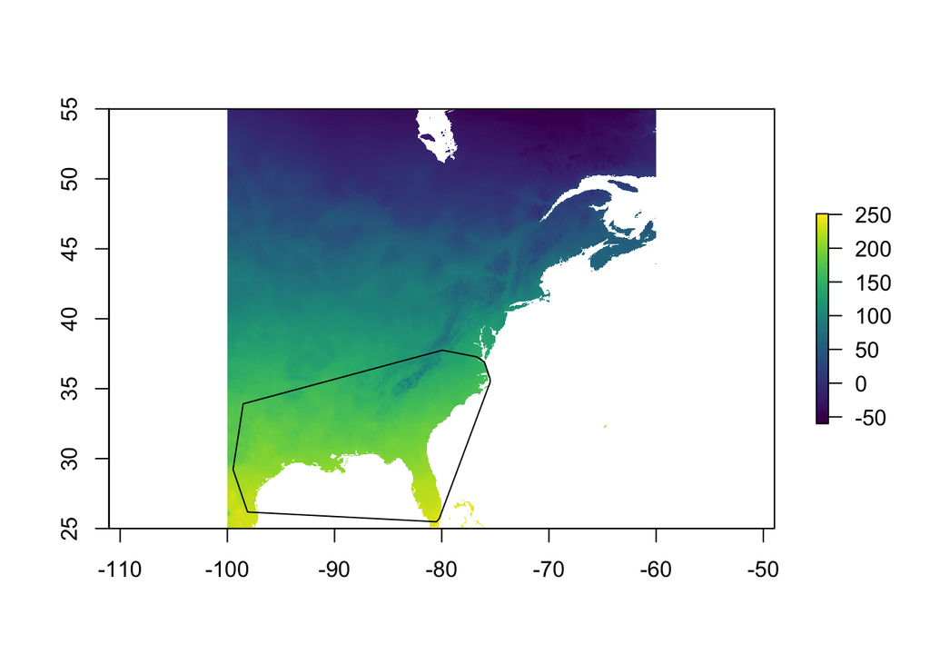

```r
#Minimum convex polygon function
mcp <- function (xy) {
  xy <- as.data.frame(coordinates(xy))
  coords.t <- chull(xy[, 1], xy[, 2])
  xy.bord <- xy[coords.t, ]
  xy.bord <- rbind(xy.bord[nrow(xy.bord), ], xy.bord)
  return(SpatialPolygons(list(Polygons(list(Polygon(as.matrix(xy.bord))), 1))))
}

MCP.thinlocs = mcp(df[,2:3])
plot(Env[[1]], col=viridis::viridis(99))
plot(MCP.thinlocs, add=T)
```

```r
envPoly <- rasterToPolygons(Env[[1]], fun=NULL, na.rm=T)

#Get bg
bg.area.thinlocs <- gIntersection(envPoly, MCP.thinlocs)
```

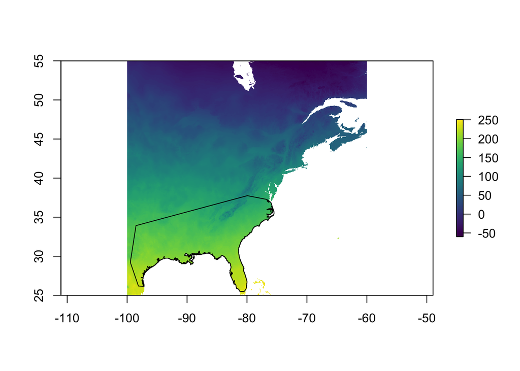

```r
MCP.raster.thinlocs <- rasterize(bg.area.thinlocs, Env[[1]])
bg.points.thinlocs <- randomPoints(mask = MCP.raster.thinlocs, n = 5000)

plot(Env[[1]], col=viridis::viridis(99))
plot(bg.area.thinlocs, add=T)
```

Use ‘bg.points.thinlocs’ to build a new best model

### ENVIREM

http://envirem.github.io/

Try the Envirem dataset instead of Worldclim

```r
enirem = stack('/data/spbio/climgrids/envirem.gri')
```

### Paleoclimate models

http://worldclim.org/paleo-climate1

The climgrids folder has several of the GCM paleoclimate outputs for the Mid Holocene and LGM scenarios provided by Worldclim and Envirem.

Use at least one of these to project a model into the past.

```r
lgm = stack('/data/spbio/climgrids/miroc/lgm_wc.gri')
names(lgm) = names(Env) #Make names match
lgm = crop(lgm, extent(Env))
lgm.pred.thin = predict(lgm,  thinres@models[[best.thin]])
```

### Homework 1

1. Pick two (or more) new species from a single genus and use ENMeval to find the best model for each.
2. Make maps of best model output for each as continuous and binary ranges.
3. Project into LGM for all 3 GCMs. (2 sp. x 3 GCMs)
4. Calculate range overlap between each LGM projection and the modern as a proxy for geographic range shift.